# Praca domowa 2

Kacper Tomczyk

## Dane

Dane wykorzystane w Pracy domowej 2 opisują wycenę nieruchmości. Każda obserwacja jest pewną nieruchmością, która posiada informacje takie jak powierzchnia, liczba pokoi, liczba łazienek i wiele więcj. Opis wszystkich kolumn w pliku `README.md`.

## Zadanie 1

Jak wygląda rozkład ceny nieruchomości w poszczególnych kodach pocztowych na przestrzeni lat? Rozważamy kody pocztowe, które mają więcej niż 280 posiadłości.

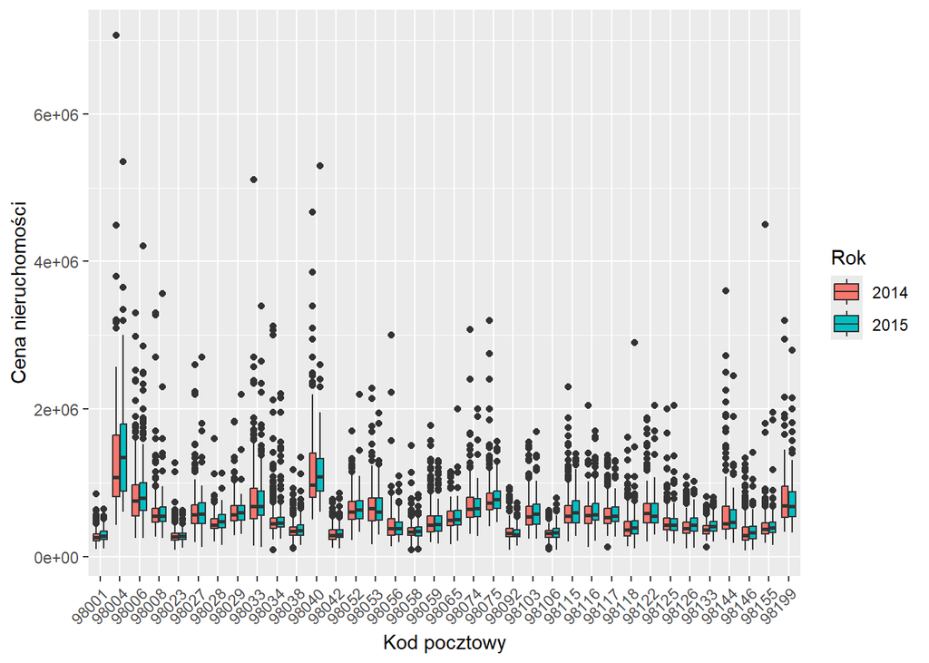

```r
# Tu umieść kod do wygenerowania odpowiedzi do zadania.
df %>%
  group_by(zipcode) %>%
  mutate(cnt = n()) %>%
  filter(cnt>280) %>%
  mutate(year =substr(date, 1, 4)) %>%
  ggplot(aes(x = factor(zipcode), y = price, fill = year)) +
  geom_boxplot()+
  labs(x = "Kod pocztowy", y = "Cena nieruchomości", fill = "Rok") +
  theme(axis.text.x = element_text(angle = 45, hjust = 1))
```

**Komentarz:** Tak rozumiem zadanie: bierzemy pod uwagę tylko dane z tych kodów pocztowych, których jest więcej niż 280. (tą filtrację robię przed ggplot’em ; musiałem jeszcze wyciągnąć z danych sam rok zakupu)

potem, tworzę boxplota (rozkład) po cenie nieruchomości (na y) i w każdym kodzie pocztowym (na x - tutaj kombinowałem, ponieważ kody pocztowe to są dane JAKOŚCIOWE, a nie ilościowe), a kolorem nad każdym kodem pocztowym oznaczyłem rok, z którego są te dane.

## Zadanie 2

Czy jest różnica w rozkładzie ceny nierchomości od powierzchni mieszkalnej uwzględniając podział na nieruchomości z piwnicą i bez?

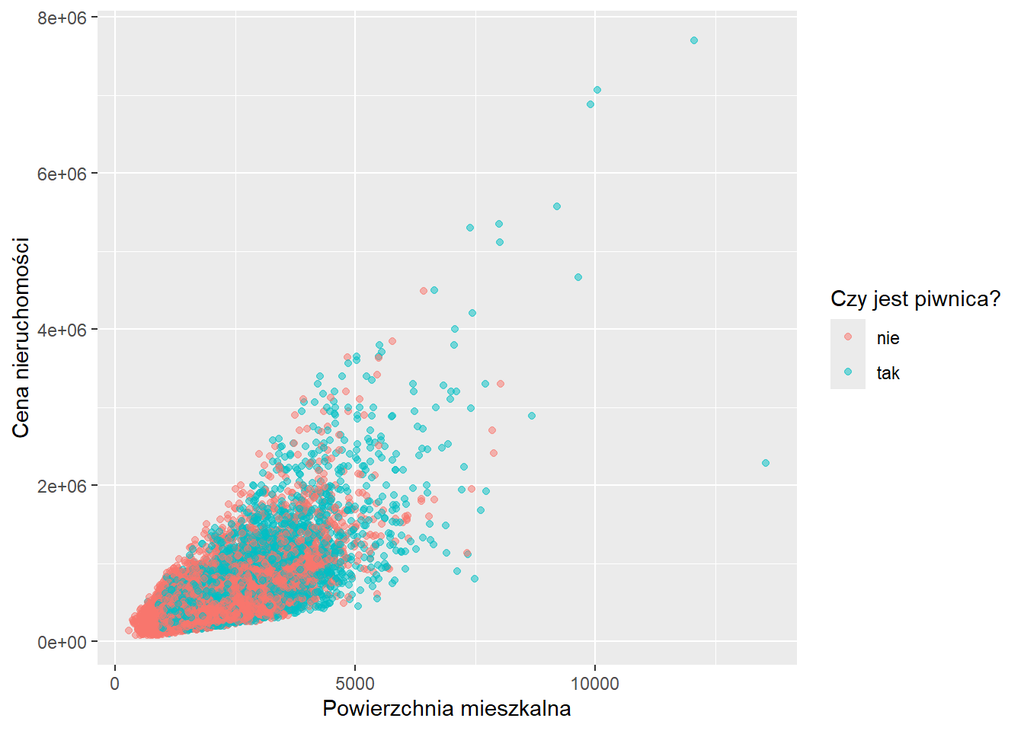

```r
# Tu umieść kod do wygenerowania odpowiedzi do zadania.

df %>%
  mutate(is_basement = ifelse(sqft_basement ==0,"nie","tak")) %>%
  ggplot(aes(x=sqft_living,y=price,color = is_basement))+
  geom_point(alpha = 0.5)+
  labs(x = "Powierzchnia mieszkalna", y = "Cena nieruchomości", color = "Czy jest piwnica?")#+
```

```r
  #facet_wrap(~is_basement)
```

**Komentarz:**

dodałem kolumne z informacją, czy w danym mieszkaniu jest piwnica, uznałem, że mam zestawić ze sobą dwie zmienne ilościowe, to najlepszym sposobem będzie wykres punktowy. Nie zauważam różnicy w rozkładzie (zakomentowana część kodu “rozczepia”wykres na dwa;pierwszy tych domów, które nie mają piwnicy, drugi-mają)

## Zadanie 3

Jaka jest zależność pomiędzy jakością wykończenia nieruchomości a liczbą pięter?

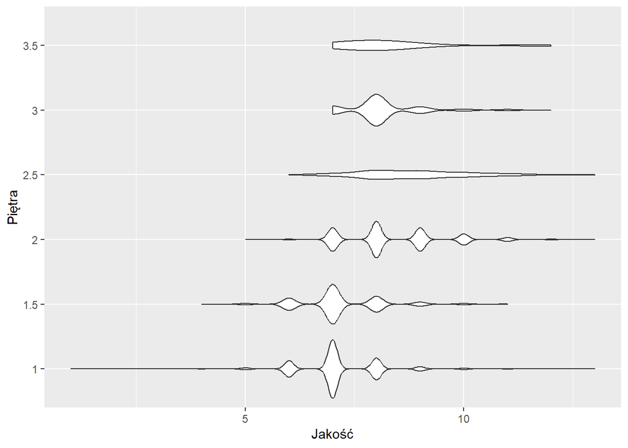

```r
# Tu umieść kod do wygenerowania odpowiedzi do zadania.
df %>%
  ggplot(aes(y=factor(floors), x = grade))+
  geom_violin()+
  #geom_boxplot()+
  labs(x = "Jakość", y = "Piętra")
```

**Komentarz:** co tu dużo komentować - zestawione dwie dane, należy się tylko zastanowić nad tym, jaki wykres najlepiej zobrazuje stan faktyczny - przy użyciu violin narzuca się tendencja rosnąća(więcej pięter - lepsze wykonanie), ale przy boxplot te “skrzynki” zmieniają swoje położenie nieregularnie (na tym samym poziomie wykończenia)

## Zadanie 4

Jaka jest zależność między powierzchnią mieszkalną nieruchomości a powierzchnią gruntu w podziale na liczbę sypialni?

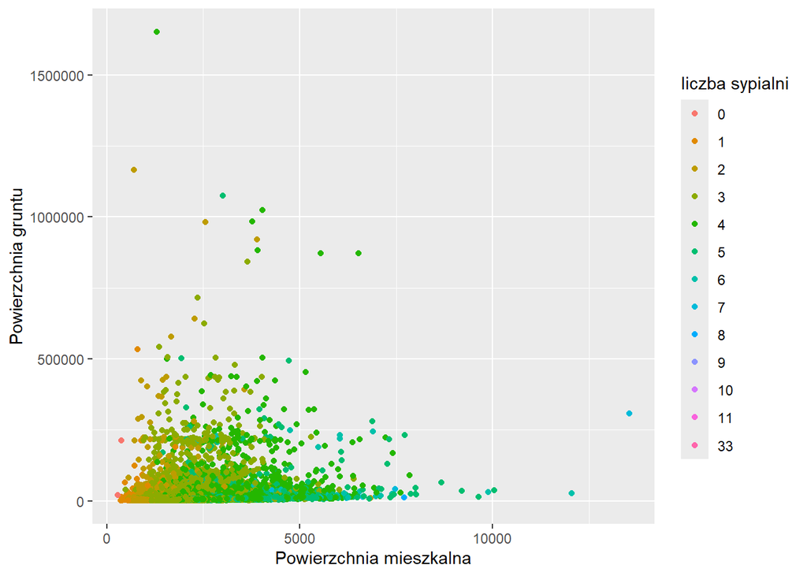

```r
# Tu umieść kod do wygenerowania odpowiedzi do zadania.
df %>%
  ggplot(aes(x=sqft_living,y=sqft_lot,color = factor(bedrooms)))+
  geom_point()+
  labs(x = "Powierzchnia mieszkalna", y = "Powierzchnia gruntu", color = "liczba sypialni")#+
```

```r
  #facet_wrap(~bedrooms)
```

**Komentarz:** ponownie, zestawiam ze soba dwie dane ilościowe, więc wykres punktowy jest najlepszym wyjściem. dodałem jeszcze kolory oznaczające liczbe sypialni w każdym domu. zakomentowana część kodu rozczepia wykres na 13 mniejszych, każdy o innej liczbie pokoi

## Zadanie 5

Rozważmy tylko nieruchomości, które miały remont. W której dekadzie było najwięcej przeprowadzonych remontów? Czy w poszczególnych dekadach jest porównywalny procent nieruchmości dla każdej wartości miary jakości i wykończenia nieruchomości?

```r
# Tu umieść kod do wygenerowania odpowiedzi do zadania.
#dekada_str <- str_sub(rok, 1, 3) %>% paste0("0")
zad_5<-df %>%
  filter(yr_renovated!=0) %>%
  mutate(decade = floor(as.numeric(yr_renovated) / 10) * 10) %>%
  group_by(decade) %>%
  mutate(count = n()) %>%
  group_by(decade,grade) %>%
  mutate(prcnt = n()/count*100) %>%
  arrange(desc(count)) %>%
  select(decade,grade,prcnt) %>%
  distinct()
cat('Najwięcej remontów było w latach:')
```

```
## Najwięcej remontów było w latach:
```

```r
cat(zad_5$decade[1])
```

```
## 2000
```

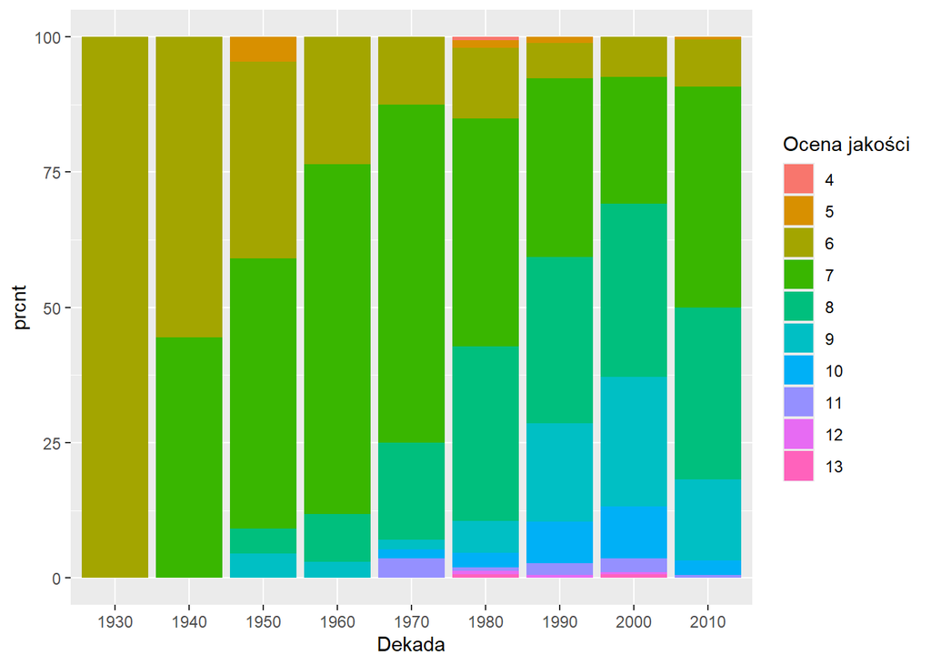

```r
zad_5 %>%
  ggplot(aes(x=factor(decade),y=prcnt,fill = factor(grade)))+
  geom_col()+
  labs(x = "Dekada", fill = "Ocena jakości")
```

**Komentarz:** Odp:Najwięcej remontów było w latach: 2000

postawiłem na geom_col przy prezentacji tych danych, ponieważ mam do zaprezentowania stan “procentowy” w każdej z “kategorii”. Zauważam, że w poszczególnych dekadach procent nieruchmości dla każdej wartości miary “jakości i wykończenia nieruchomości” nie jest porównywalny i zmieniał się w czasie.

## Zadanie 6

Jak prezentuje się wartość minimalna, średnia i maksymalna ceny nieruchmości w podziele na rok budowy nieruchomości.

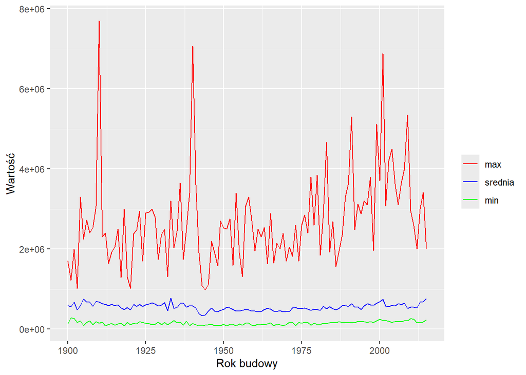

```r
# Tu umieść kod do wygenerowania odpowiedzi do zadania.

df %>%
  group_by(yr_built) %>%
  mutate(min = min(price),
         srednia = mean(price),
         max = max(price)) %>%
  select(yr_built,min,srednia,max) %>%
  distinct() %>%
  pivot_longer(cols = c(min, srednia,max),
               names_to = "typ",
               values_to = "wartosc") %>%
  ggplot(aes(x=yr_built,y=wartosc, color = typ))+
  geom_line()+
  labs(x = "Rok budowy", y = "Wartość", color = "")+
  scale_color_manual(values = c("max" = "red", "srednia" = "blue", "min" = "green"),
                     breaks = c("max", "srednia", "min"))
```

**Komentarz:**

wykres słada się z 3 prostych - można zauważyć, że proste min i średnia mają znacznie mniejsze uskoki niż max. Trudno jest zauważyć jakąkolwiek tendencję w tych wykresach.